# Report for hubline

## 1. The Data

Here is your dataset as we reprocessed it. Please take a look.

**Click to see the clean data**

```r
#
 study_data |>
          kable( format = "html") %>%
          kable_styling(position = "center", full_width = F, bootstrap_options = c("striped","hover"))%>%
          scroll_box( width = "1000px", height = "500px", fixed_thead = T)
```

| Entry | Study | Region | Site | Depth.m | Sample.Year | Sample.Month | Sample.Day | Latitude | Longitude | Taxon | Fixed.or.Random | Sample.Unit.Size.sq.m | Percent.Cover | Stipe.Density.num.per.sq.m | Individual.Density.num.per.sq.m | Biomass.kg.wet.per.sq.m |
| --- | --- | --- | --- | --- | --- | --- | --- | --- | --- | --- | --- | --- | --- | --- | --- | --- |
| 1 | hubline | NA | Site29 | 10 | 2006 | 6 | 14 | 42.34382 | -70.90657 | Laminaria sp. | Random | 1 | 0.5 | 1 | NA | NA |
| 2 | hubline | NA | Site29 | 10 | 2006 | 6 | 14 | 42.34382 | -70.90657 | Laminaria sp. | Random | 1 | 15.0 | 1 | NA | NA |
| 3 | hubline | NA | Site29 | 10 | 2006 | 6 | 14 | 42.34382 | -70.90657 | Laminaria sp. | Random | 1 | 0.5 | 3 | NA | NA |
| 4 | hubline | NA | Site29 | 10 | 2006 | 6 | 14 | 42.34382 | -70.90657 | Laminaria sp. | Random | 1 | 0.5 | 2 | NA | NA |
| 5 | hubline | NA | Site29 | 10 | 2006 | 6 | 14 | 42.34382 | -70.90657 | Laminaria sp. | Random | 1 | 0.5 | 1 | NA | NA |
| 6 | hubline | NA | Site29 | 10 | 2006 | 6 | 14 | 42.34382 | -70.90657 | Laminaria sp. | Random | 1 | 1.0 | 2 | NA | NA |
| 7 | hubline | NA | NatReef | 10 | 2006 | 7 | 6 | 42.33844 | -70.91263 | Laminaria sp. | Random | 1 | 5.0 | 20 | NA | NA |
| 8 | hubline | NA | NatReef | 10 | 2006 | 7 | 6 | 42.33844 | -70.91263 | Laminaria sp. | Random | 1 | 18.0 | 11 | NA | NA |
| 9 | hubline | NA | NatReef | 10 | 2006 | 7 | 6 | 42.33844 | -70.91263 | Laminaria sp. | Random | 1 | 12.0 | 22 | NA | NA |
| 10 | hubline | NA | NatReef | 10 | 2006 | 7 | 6 | 42.33844 | -70.91263 | Laminaria sp. | Random | 1 | 30.0 | 14 | NA | NA |
| 11 | hubline | NA | NatReef | 10 | 2006 | 7 | 6 | 42.33844 | -70.91263 | Laminaria sp. | Random | 1 | 30.0 | 19 | NA | NA |
| 12 | hubline | NA | NatReef | 10 | 2006 | 7 | 5 | 42.33844 | -70.91263 | Laminaria sp. | Random | 1 | 25.0 | 10 | NA | NA |
| 13 | hubline | NA | NatReef | 10 | 2006 | 7 | 5 | 42.33844 | -70.91263 | Laminaria sp. | Random | 1 | 2.0 | 5 | NA | NA |
| 14 | hubline | NA | NatReef | 10 | 2006 | 7 | 5 | 42.33844 | -70.91263 | Laminaria sp. | Random | 1 | 5.0 | 2 | NA | NA |
| 15 | hubline | NA | NatReef | 10 | 2006 | 7 | 5 | 42.33844 | -70.91263 | Laminaria sp. | Random | 1 | 3.0 | 14 | NA | NA |
| 16 | hubline | NA | NatReef | 10 | 2006 | 7 | 5 | 42.33844 | -70.91263 | Laminaria sp. | Random | 1 | 2.0 | 8 | NA | NA |
| 17 | hubline | NA | NatReef | 10 | 2006 | 7 | 5 | 42.33844 | -70.91263 | Laminaria sp. | Random | 1 | 10.0 | 3 | NA | NA |
| 18 | hubline | NA | NatReef | 10 | 2006 | 7 | 5 | 42.33844 | -70.91263 | Laminaria sp. | Random | 1 | 35.0 | 6 | NA | NA |
| 19 | hubline | NA | NatReef | 10 | 2006 | 7 | 5 | 42.33844 | -70.91263 | Laminaria sp. | Random | 1 | 10.0 | 4 | NA | NA |
| 20 | hubline | NA | NatReef | 10 | 2006 | 7 | 5 | 42.33844 | -70.91263 | Laminaria sp. | Random | 1 | 18.0 | 4 | NA | NA |
| 21 | hubline | NA | NatReef | 10 | 2006 | 7 | 5 | 42.33844 | -70.91263 | Laminaria sp. | Random | 1 | 7.0 | 9 | NA | NA |
| 22 | hubline | NA | NatReef | 10 | 2006 | 7 | 5 | 42.33844 | -70.91263 | Laminaria sp. | Random | 1 | 5.0 | 5 | NA | NA |
| 23 | hubline | NA | HublineFill | 10 | 2006 | 7 | 5 | 42.34370 | -70.90597 | Laminaria sp. | Random | 1 | 3.0 | 4 | NA | NA |
| 24 | hubline | NA | HublineFill | 10 | 2006 | 7 | 5 | 42.34370 | -70.90597 | Laminaria sp. | Random | 1 | 30.0 | 2 | NA | NA |
| 25 | hubline | NA | HublineFill | 10 | 2006 | 7 | 5 | 42.34370 | -70.90597 | Laminaria sp. | Random | 1 | 15.0 | 2 | NA | NA |
| 26 | hubline | NA | HublineFill | 10 | 2006 | 7 | 5 | 42.34370 | -70.90597 | Laminaria sp. | Random | 1 | 5.0 | 2 | NA | NA |
| 27 | hubline | NA | HublineFill | 10 | 2006 | 7 | 5 | 42.34370 | -70.90597 | Laminaria sp. | Random | 1 | 15.0 | 1 | NA | NA |
| 28 | hubline | NA | HublineFill | 10 | 2006 | 7 | 6 | 42.34370 | -70.90597 | Laminaria sp. | Random | 1 | 7.0 | 48 | NA | NA |
| 29 | hubline | NA | HublineFill | 10 | 2006 | 7 | 6 | 42.34370 | -70.90597 | Laminaria sp. | Random | 1 | 8.0 | 18 | NA | NA |
| 30 | hubline | NA | HublineFill | 10 | 2006 | 7 | 6 | 42.34370 | -70.90597 | Laminaria sp. | Random | 1 | 25.0 | 8 | NA | NA |

[output cut: 1231 more lines]

Here is your dataset as where we have now summed across all kelp species and put into the KelpTime main database format.

**Click to see the data in kelptime format**

```r
#|
kelptime_study |>
         kable( format = "html") %>%
         kable_styling(position = "center", full_width = F, bootstrap_options = c("striped","hover"))%>%
         scroll_box( width = "1000px", height = "500px", fixed_thead = T)
```

| study | site | period | latitude | longitude | sample_unit_size_sq_m | sasdate | max_depth | mean_depth | min_depth | biomass_kg_wet_per_sq_m | stipe_density_num_per_sq_m | individual_density_num_per_sq_m | percent_cover | has_bm | has_sd | has_id | has_pc | use_which | focalKelp | focalUnit | geometry | ecoregion | province | realm | focal_std_by_ecoregion | focal_std_by_province | focal_std_by_realm | ln_focal_std_by_ecoregion | ln_focal_std_by_province | … |
| --- | --- | --- | --- | --- | --- | --- | --- | --- | --- | --- | --- | --- | --- | --- | --- | --- | --- | --- | --- | --- | --- | --- | --- | --- | --- | --- | --- | --- | --- | --- |
| hubline | HublineFill | 1 | 42.34370 | -70.90597 | 1 | 2006-07-05 | 10 | 10 | 10 | NA | 2.2000000 | 2.2000000 | 13.6000000 | 0 | 91 | 91 | 91 | 2 | 2.2000000 | Stipe density | c(-70.90597, 42.3437) | Gulf of Maine/Bay of Fundy | Cold Temperate Northwest Atlantic | Temperate Northern Atlantic | 0.0380967 | 0.0088276 | 0.0088276 | -3.0345421 | -3.972431 | … |
| hubline | HublineFill | 2 | 42.34370 | -70.90597 | 1 | 2006-07-06 | 10 | 10 | 10 | NA | 16.8888889 | 16.8888889 | 26.6666667 | 0 | 91 | 91 | 91 | 2 | 16.8888889 | Stipe density | c(-70.90597, 42.3437) | Gulf of Maine/Bay of Fundy | Cold Temperate Northwest Atlantic | Temperate Northern Atlantic | 0.2924594 | 0.0677675 | 0.0677675 | -1.1958083 | -2.554032 | … |
| hubline | HublineFill | 3 | 42.34295 | -70.90664 | 1 | 2006-07-18 | 10 | 10 | 10 | NA | 6.9375000 | 6.9375000 | 0.7812500 | 0 | 91 | 91 | 91 | 2 | 6.9375000 | Stipe density | c(-70.90664, 42.342945) | Gulf of Maine/Bay of Fundy | Cold Temperate Northwest Atlantic | Temperate Northern Atlantic | 0.1201344 | 0.0278371 | 0.0278371 | -2.0391873 | -3.274466 | … |
| hubline | HublineFill | 4 | 42.34370 | -70.90597 | 1 | 2006-08-02 | 10 | 10 | 10 | NA | 22.6250000 | 22.6250000 | 28.6250000 | 0 | 91 | 91 | 91 | 2 | 22.6250000 | Stipe density | c(-70.90597, 42.3437) | Gulf of Maine/Bay of Fundy | Cold Temperate Northwest Atlantic | Temperate Northern Atlantic | 0.3917897 | 0.0907839 | 0.0907839 | -0.9118263 | -2.294776 | … |
| hubline | HublineFill | 5 | 42.34295 | -70.90664 | 1 | 2006-08-10 | 10 | 10 | 10 | NA | 9.8750000 | 9.8750000 | 2.1250000 | 0 | 91 | 91 | 91 | 2 | 9.8750000 | Stipe density | c(-70.90664, 42.342945) | Gulf of Maine/Bay of Fundy | Cold Temperate Northwest Atlantic | Temperate Northern Atlantic | 0.1710022 | 0.0396239 | 0.0396239 | -1.7092463 | -3.003282 | … |
| hubline | HublineFill | 6 | 42.34224 | -70.90703 | 1 | 2006-09-22 | 10 | 10 | 10 | NA | 1.0000000 | 1.0000000 | 0.5000000 | 0 | 91 | 91 | 91 | 2 | 1.0000000 | Stipe density | c(-70.907035, 42.34224) | Gulf of Maine/Bay of Fundy | Cold Temperate Northwest Atlantic | Temperate Northern Atlantic | 0.0173167 | 0.0040125 | 0.0040125 | -3.6002580 | -4.267802 | … |
| hubline | HublineFill | 7 | 42.34295 | -70.90664 | 1 | 2006-11-20 | 10 | 10 | 10 | NA | 1.2000000 | 1.2000000 | 0.9000000 | 0 | 91 | 91 | 91 | 2 | 1.2000000 | Stipe density | c(-70.90664, 42.342945) | Gulf of Maine/Bay of Fundy | Cold Temperate Northwest Atlantic | Temperate Northern Atlantic | 0.0207800 | 0.0048151 | 0.0048151 | -3.4808899 | -4.212111 | … |
| hubline | HublineFill | 8 | 42.34370 | -70.90597 | 1 | 2007-03-14 | 10 | 10 | 10 | NA | 1.2500000 | 1.2500000 | 0.6250000 | 0 | 91 | 91 | 91 | 2 | 1.2500000 | Stipe density | c(-70.90597, 42.3437) | Gulf of Maine/Bay of Fundy | Cold Temperate Northwest Atlantic | Temperate Northern Atlantic | 0.0216458 | 0.0050157 | 0.0050157 | -3.4531485 | -4.198660 | … |
| hubline | HublineFill | 9 | 42.34295 | -70.90664 | 1 | 2007-05-23 | 10 | 10 | 10 | NA | 2.0000000 | 2.0000000 | 1.0000000 | 0 | 91 | 91 | 91 | 2 | 2.0000000 | Stipe density | c(-70.90664, 42.342945) | Gulf of Maine/Bay of Fundy | Cold Temperate Northwest Atlantic | Temperate Northern Atlantic | 0.0346333 | 0.0080251 | 0.0080251 | -3.1092740 | -4.015990 | … |
| hubline | HublineFill | 10 | 42.34370 | -70.90597 | 1 | 2007-06-19 | 10 | 10 | 10 | NA | 3.4375000 | 3.4375000 | 6.3750000 | 0 | 91 | 91 | 91 | 2 | 3.4375000 | Stipe density | c(-70.90597, 42.3437) | Gulf of Maine/Bay of Fundy | Cold Temperate Northwest Atlantic | Temperate Northern Atlantic | 0.0595261 | 0.0137931 | 0.0137931 | -2.6660535 | -3.738358 | … |
| hubline | HublineFill | 11 | 42.34224 | -70.90703 | 1 | 2007-06-20 | 10 | 10 | 10 | NA | 2.8461538 | 2.8461538 | 1.0000000 | 0 | 91 | 91 | 91 | 2 | 2.8461538 | Stipe density | c(-70.907035, 42.34224) | Gulf of Maine/Bay of Fundy | Cold Temperate Northwest Atlantic | Temperate Northern Atlantic | 0.0492859 | 0.0114203 | 0.0114203 | -2.8253835 | -3.843415 | … |
| hubline | HublineFill | 12 | 42.34339 | -70.90625 | 1 | 2007-07-17 | 10 | 10 | 10 | NA | 2.2352941 | 2.2352941 | 2.7941176 | 0 | 91 | 91 | 91 | 2 | 2.2352941 | Stipe density | c(-70.9062458823529, 42.3433891176471) | Gulf of Maine/Bay of Fundy | Cold Temperate Northwest Atlantic | Temperate Northern Atlantic | 0.0387079 | 0.0089692 | 0.0089692 | -3.0219149 | -3.964937 | … |
| hubline | HublineFill | 13 | 42.34295 | -70.90664 | 1 | 2008-07-17 | 10 | 10 | 10 | NA | 2.8000000 | 2.8000000 | 6.8500000 | 0 | 91 | 91 | 91 | 2 | 2.8000000 | Stipe density | c(-70.90664, 42.342945) | Gulf of Maine/Bay of Fundy | Cold Temperate Northwest Atlantic | Temperate Northern Atlantic | 0.0484867 | 0.0112351 | 0.0112351 | -2.8389561 | -3.852098 | … |
| hubline | NatReef | 1 | 42.33844 | -70.91263 | 1 | 2006-07-05 | 10 | 10 | 10 | NA | 6.3636364 | 6.3636364 | 11.0909091 | 0 | 91 | 91 | 91 | 2 | 6.3636364 | Stipe density | c(-70.912625, 42.33844) | Gulf of Maine/Bay of Fundy | Cold Temperate Northwest Atlantic | Temperate Northern Atlantic | 0.1101970 | 0.0255344 | 0.0255344 | -2.1186231 | -3.337254 | … |
| hubline | NatReef | 2 | 42.33844 | -70.91263 | 1 | 2006-07-06 | 10 | 10 | 10 | NA | 17.2000000 | 17.2000000 | 19.0000000 | 0 | 91 | 91 | 91 | 2 | 17.2000000 | Stipe density | c(-70.912625, 42.33844) | Gulf of Maine/Bay of Fundy | Cold Temperate Northwest Atlantic | Temperate Northern Atlantic | 0.2978468 | 0.0690159 | 0.0690159 | -1.1781530 | -2.538107 | … |
| hubline | NatReef | 3 | 42.33828 | -70.91309 | 1 | 2006-07-19 | 10 | 10 | 10 | NA | 11.2222222 | 11.2222222 | 28.0000000 | 0 | 91 | 91 | 91 | 2 | 11.2222222 | Stipe density | c(-70.913095, 42.338275) | Gulf of Maine/Bay of Fundy | Cold Temperate Northwest Atlantic | Temperate Northern Atlantic | 0.1943316 | 0.0450297 | 0.0450297 | -1.5880113 | -2.899882 | … |
| hubline | NatReef | 4 | 42.33828 | -70.91209 | 1 | 2006-07-26 | 10 | 10 | 10 | NA | 21.2666667 | 21.2666667 | 5.4666667 | 0 | 91 | 91 | 91 | 2 | 21.2666667 | Stipe density | c(-70.91209, 42.338285) | Gulf of Maine/Bay of Fundy | Cold Temperate Northwest Atlantic | Temperate Northern Atlantic | 0.3682679 | 0.0853336 | 0.0853336 | -0.9721525 | -2.350373 | … |
| hubline | NatReef | 5 | 42.33844 | -70.91263 | 1 | 2006-08-01 | 10 | 10 | 10 | NA | 9.3333333 | 9.3333333 | 12.0333333 | 0 | 91 | 91 | 91 | 2 | 9.3333333 | Stipe density | c(-70.912625, 42.33844) | Gulf of Maine/Bay of Fundy | Cold Temperate Northwest Atlantic | Temperate Northern Atlantic | 0.1616223 | 0.0374505 | 0.0374505 | -1.7624592 | -3.048069 | … |
| hubline | NatReef | 6 | 42.33828 | -70.91309 | 1 | 2006-08-03 | 10 | 10 | 10 | NA | 7.2500000 | 7.2500000 | 21.2500000 | 0 | 91 | 91 | 91 | 2 | 7.2500000 | Stipe density | c(-70.913095, 42.338275) | Gulf of Maine/Bay of Fundy | Cold Temperate Northwest Atlantic | Temperate Northern Atlantic | 0.1255459 | 0.0290910 | 0.0290910 | -1.9984451 | -3.241863 | … |
| hubline | NatReef | 7 | 42.33828 | -70.91209 | 1 | 2006-09-25 | 10 | 10 | 10 | NA | 1.7692308 | 1.7692308 | 1.9615385 | 0 | 91 | 91 | 91 | 2 | 1.7692308 | Stipe density | c(-70.91209, 42.338285) | Gulf of Maine/Bay of Fundy | Cold Temperate Northwest Atlantic | Temperate Northern Atlantic | 0.0306372 | 0.0070991 | 0.0070991 | -3.2030716 | -4.068728 | … |
| hubline | NatReef | 8 | 42.33828 | -70.91309 | 1 | 2006-12-05 | 10 | 10 | 10 | NA | 1.0000000 | 1.0000000 | 1.6000000 | 0 | 91 | 91 | 91 | 2 | 1.0000000 | Stipe density | c(-70.913095, 42.338275) | Gulf of Maine/Bay of Fundy | Cold Temperate Northwest Atlantic | Temperate Northern Atlantic | 0.0173167 | 0.0040125 | 0.0040125 | -3.6002580 | -4.267802 | … |
| hubline | NatReef | 9 | 42.33844 | -70.91263 | 1 | 2006-12-07 | 10 | 10 | 10 | NA | 1.0000000 | 1.0000000 | 1.3333333 | 0 | 91 | 91 | 91 | 2 | 1.0000000 | Stipe density | c(-70.912625, 42.33844) | Gulf of Maine/Bay of Fundy | Cold Temperate Northwest Atlantic | Temperate Northern Atlantic | 0.0173167 | 0.0040125 | 0.0040125 | -3.6002580 | -4.267802 | … |
| hubline | NatReef | 10 | 42.33828 | -70.91209 | 1 | 2007-03-01 | 10 | 10 | 10 | NA | 1.1428571 | 1.1428571 | 0.7857143 | 0 | 91 | 91 | 91 | 2 | 1.1428571 | Stipe density | c(-70.91209, 42.338285) | Gulf of Maine/Bay of Fundy | Cold Temperate Northwest Atlantic | Temperate Northern Atlantic | 0.0197905 | 0.0045858 | 0.0045858 | -3.5135662 | -4.227709 | … |
| hubline | NatReef | 11 | 42.33828 | -70.91309 | 1 | 2007-03-12 | 10 | 10 | 10 | NA | 1.5000000 | 1.5000000 | 0.7500000 | 0 | 91 | 91 | 91 | 2 | 1.5000000 | Stipe density | c(-70.913095, 42.338275) | Gulf of Maine/Bay of Fundy | Cold Temperate Northwest Atlantic | Temperate Northern Atlantic | 0.0259750 | 0.0060188 | 0.0060188 | -3.3249307 | -4.133991 | … |
| hubline | NatReef | 12 | 42.33836 | -70.91286 | 1 | 2007-03-14 | 10 | 10 | 10 | NA | 1.5000000 | 1.5000000 | 0.7500000 | 0 | 91 | 91 | 91 | 2 | 1.5000000 | Stipe density | c(-70.91286, 42.3383575) | Gulf of Maine/Bay of Fundy | Cold Temperate Northwest Atlantic | Temperate Northern Atlantic | 0.0259750 | 0.0060188 | 0.0060188 | -3.3249307 | -4.133991 | … |
| hubline | NatReef | 13 | 42.33844 | -70.91263 | 1 | 2007-04-11 | 10 | 10 | 10 | NA | 1.5454545 | 1.5454545 | 1.4545455 | 0 | 91 | 91 | 91 | 2 | 1.5454545 | Stipe density | c(-70.912625, 42.33844) | Gulf of Maine/Bay of Fundy | Cold Temperate Northwest Atlantic | Temperate Northern Atlantic | 0.0267621 | 0.0062012 | 0.0062012 | -3.3032870 | -4.122669 | … |
| hubline | NatReef | 14 | 42.33844 | -70.91263 | 1 | 2007-05-24 | 10 | 10 | 10 | NA | 1.8571429 | 1.8571429 | 3.0000000 | 0 | 91 | 91 | 91 | 2 | 1.8571429 | Stipe density | c(-70.912625, 42.33844) | Gulf of Maine/Bay of Fundy | Cold Temperate Northwest Atlantic | Temperate Northern Atlantic | 0.0321595 | 0.0074519 | 0.0074519 | -3.1662943 | -4.048308 | … |
| hubline | NatReef | 15 | 42.33828 | -70.91309 | 1 | 2007-06-01 | 10 | 10 | 10 | NA | 5.1875000 | 5.1875000 | 5.1562500 | 0 | 91 | 91 | 91 | 2 | 5.1875000 | Stipe density | c(-70.913095, 42.338275) | Gulf of Maine/Bay of Fundy | Cold Temperate Northwest Atlantic | Temperate Northern Atlantic | 0.0898302 | 0.0208151 | 0.0208151 | -2.3042841 | -3.479750 | … |
| hubline | NatReef | 16 | 42.33828 | -70.91209 | 1 | 2007-06-18 | 10 | 10 | 10 | NA | 4.3571429 | 4.3571429 | 2.6428571 | 0 | 91 | 91 | 91 | 2 | 4.3571429 | Stipe density | c(-70.91209, 42.338285) | Gulf of Maine/Bay of Fundy | Cold Temperate Northwest Atlantic | Temperate Northern Atlantic | 0.0754512 | 0.0174833 | 0.0174833 | -2.4598096 | -3.594178 | … |
| hubline | NatReef | 17 | 42.33844 | -70.91263 | 1 | 2007-07-17 | 10 | 10 | 10 | NA | 1.6666667 | 1.6666667 | 1.5000000 | 0 | 91 | 91 | 91 | 2 | 1.6666667 | Stipe density | c(-70.912625, 42.33844) | Gulf of Maine/Bay of Fundy | Cold Temperate Northwest Atlantic | Temperate Northern Atlantic | 0.0288611 | 0.0066876 | 0.0066876 | -3.2477609 | -4.093090 | … |

[output cut: 61 more lines]

## 2. Plots of raw data

### 2.1 By metric

Here is what your data looks like with all sites plotted together looking at each sampling metric.

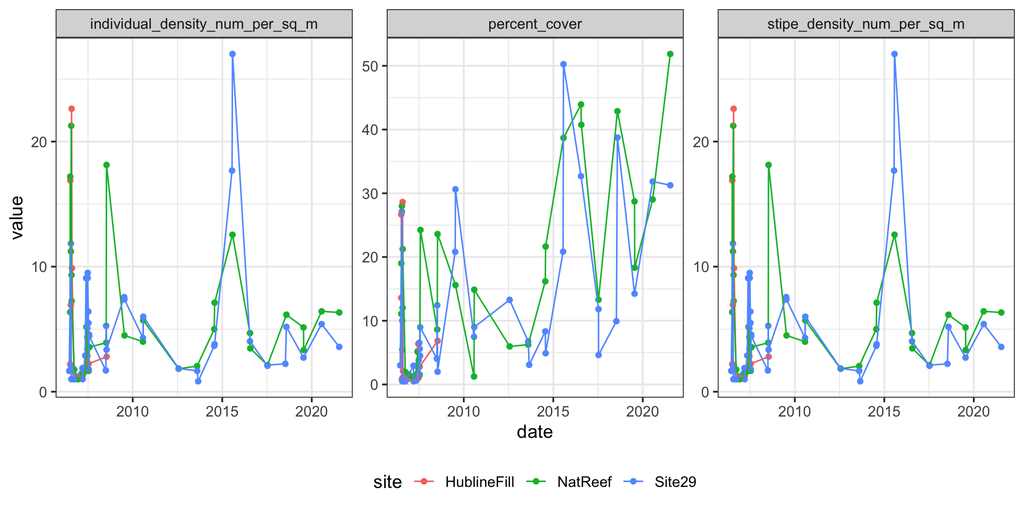

```r
kelptime_study_measurement_long <-
  kelptime_study |>
  tidyr::pivot_longer(cols =biomass_kg_wet_per_sq_m:percent_cover) |>
  filter(!is.na(value))

ggplot(kelptime_study_measurement_long,
       aes(x = date, y = value,
           color = site)) +
  geom_point() +
  geom_line() +
  facet_wrap(vars(name), scale = "free_y")
```

### 2.2 Standardized data

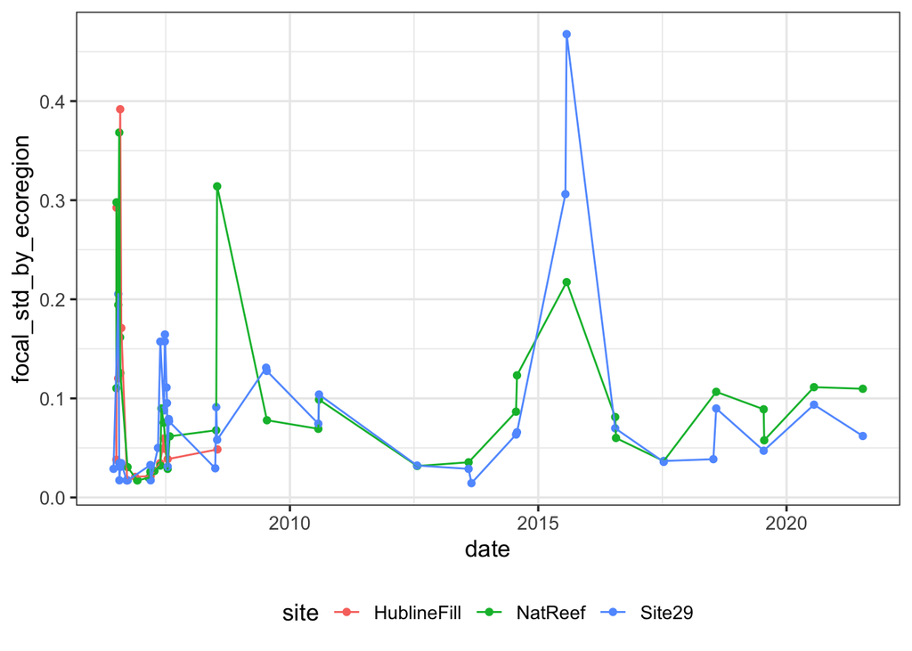

```r
ggplot(kelptime_study,
       aes(x = date, y = focal_std_by_ecoregion,
           color = site)) +
  geom_point() +
  geom_line()
```

### 2.3 Standardized data by site

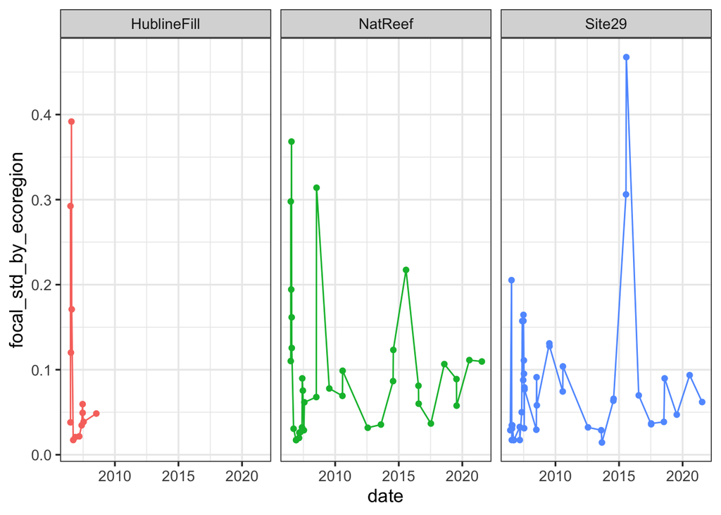

```r
ggplot(kelptime_study,
       aes(x = date, y = focal_std_by_ecoregion,
           color = site)) +
  geom_point() +
  geom_line() +
  facet_wrap(vars(site)) +
  guides(color = "none")
```

## 3. Modeled timeseries resuls

We fit two models. One where the slope varies by ecoregion (note: the GOSL and Newfoundland are collapsed) and one where the slope does not vary by ecoregion. Based on the modeled results, here is the smoothed fits to your data. Note - thus far, the model with a common slope appears to be the correct is the one with a common slope (best fit in terms of prediction and p-value for slope*ecoregion is not distinguishable from 0).

**Note** - the study (black) line might not line up in the middle or on trajectories, as it is shrunken in towards the grand mean for the ecoregion.

### 3.1 Slope Varying by Ecoregion Model

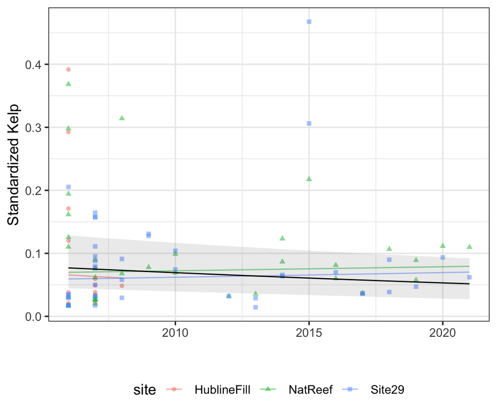

```r
mod_ecoregion <- readRDS("models/mod_ecoregion.rds")


# for plotting to do the back transform
exp_trans <- function(dat){

  dat |>
    mutate(
      Predicted = exp(Predicted)-0.01,
           CI_low = exp(CI_low)-0.01,
           CI_high = exp(CI_high)-0.01,
           CI_high = ifelse(CI_high>1.1, 1.1, CI_high)
    )|>
               mutate(trajectory =
                        gsub(study[1], "", trajectory))

}


re_ecoregion <- ranef(mod_ecoregion)$cond$study |>
  as_tibble(rownames = "study")  |>
  filter(study == params$study) |>
  pull(`(Intercept)`)


dat_fixed_ecoregion <- estimate_relation(mod_ecoregion,
                               include_random = FALSE,
                  length = 200,
                  data = kelptime_study) |>
  mutate(Predicted = Predicted + re_ecoregion,
         CI_high = CI_high + re_ecoregion,
         CI_low = CI_low + re_ecoregion) |>
  exp_trans()

dat_traj_ecoregion <- estimate_relation(mod_ecoregion,
                              include_random = TRUE,
                  length = 200,
                  data = kelptime_study) |>
    exp_trans()


ggplot(dat_traj_ecoregion, aes(x = year)) +
  geom_line(aes(y = Predicted,
                color = trajectory), alpha = 0.5) +
  geom_point(aes(y = focal_std_by_ecoregion,
                 group = trajectory,
                 shape = trajectory,
                 color = trajectory), alpha = 0.5,
             data = kelptime_study |>
               mutate(trajectory =
                        gsub(study[1], "", trajectory))) +
  geom_line(data = dat_fixed_ecoregion,
            aes(y = Predicted), color = "black") +
  geom_ribbon(data = dat_fixed_ecoregion,
            aes(y = Predicted,
                ymin = CI_low,
                ymax = CI_high), color = NA,
            alpha = 0.1) +
  labs(x = "", y = "Standardized Kelp",
      color = "site", shape = "site")
```

### 3.2 Common Slope Model

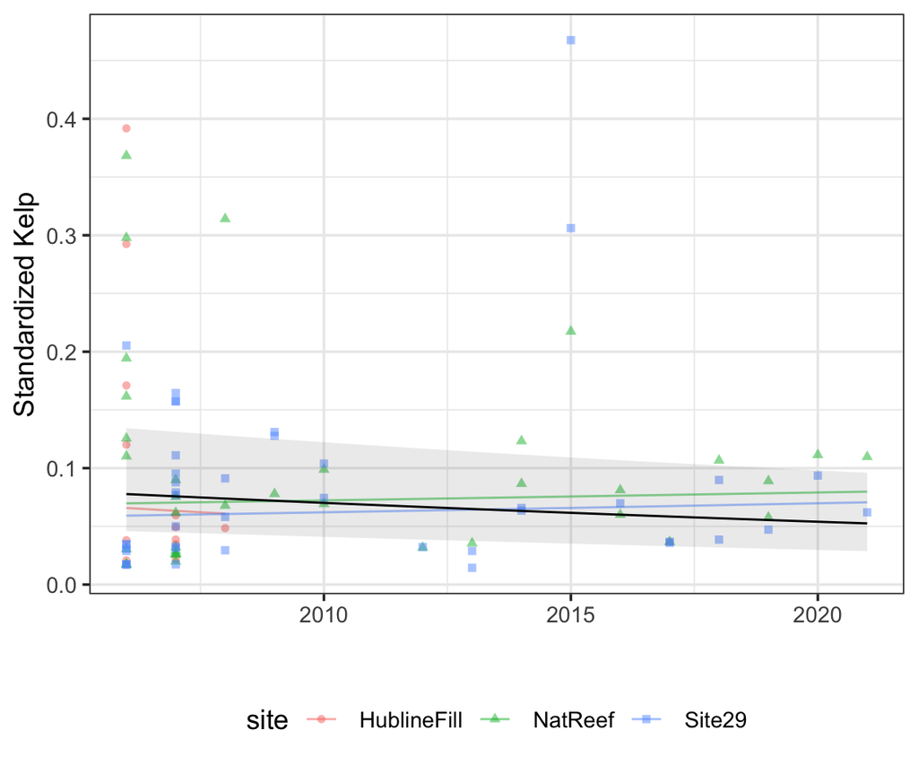

```r
mod_common_slope <- readRDS("models/mod_common_slope.rds")

re <- ranef(mod_common_slope)$cond$study |>
  as_tibble(rownames = "study")  |>
  filter(study == params$study) |>
  pull(`(Intercept)`)


dat_fixed <- estimate_relation(mod_common_slope,
                               include_random = FALSE,
                  length = 200,
                  data = kelptime_study) |>
  mutate(Predicted = Predicted + re,
         CI_high = CI_high + re_ecoregion,
         CI_low = CI_low + re_ecoregion) |>
  exp_trans()

dat_traj <- estimate_relation(mod_common_slope,
                              include_random = TRUE,
                  length = 200,
                  data = kelptime_study) |>
    exp_trans()

ggplot(dat_traj, aes(x = year)) +
  geom_line(aes(y = Predicted,
                color = trajectory), alpha = 0.5) +
  geom_point(aes(y = focal_std_by_ecoregion,
                 group = trajectory,
                 shape = trajectory,
                 color = trajectory), alpha = 0.5,
             data = kelptime_study |>
               mutate(trajectory =
                        gsub(study[1], "", trajectory))) +
  geom_line(data = dat_fixed,
            aes(y = Predicted), color = "black") +
  geom_ribbon(data = dat_fixed,
            aes(y = Predicted,
                ymin = CI_low,
                ymax = CI_high), color = NA,
            alpha = 0.1) +
  labs(x = "", y = "Standardized Kelp",
      color = "site", shape = "site")
```